# ar_stuff.R

John Flournoy

Wed Dec 5 20:14:42 2018

```r
library(simsem)
library(nlme)
library(lmerTest)
library(lme4)
library(semPlot)
library(dplyr)
library(tidyr)
```

We want to sample data from a null model where *x* and *y* are correlated over time (due to some shared influences), but are *not* causally related. This is the null model we’re implicitly testing against, so we need to know that our procedure’s error rate performance is as expected (that is, that if we set $\alpha=.05$ we’re actually controlling or error rate at 5%). I’ve created a model that has *x* and *y* observed at 12 occasions, with x and y having high stability (.7) and being somewhat correlated (.5).

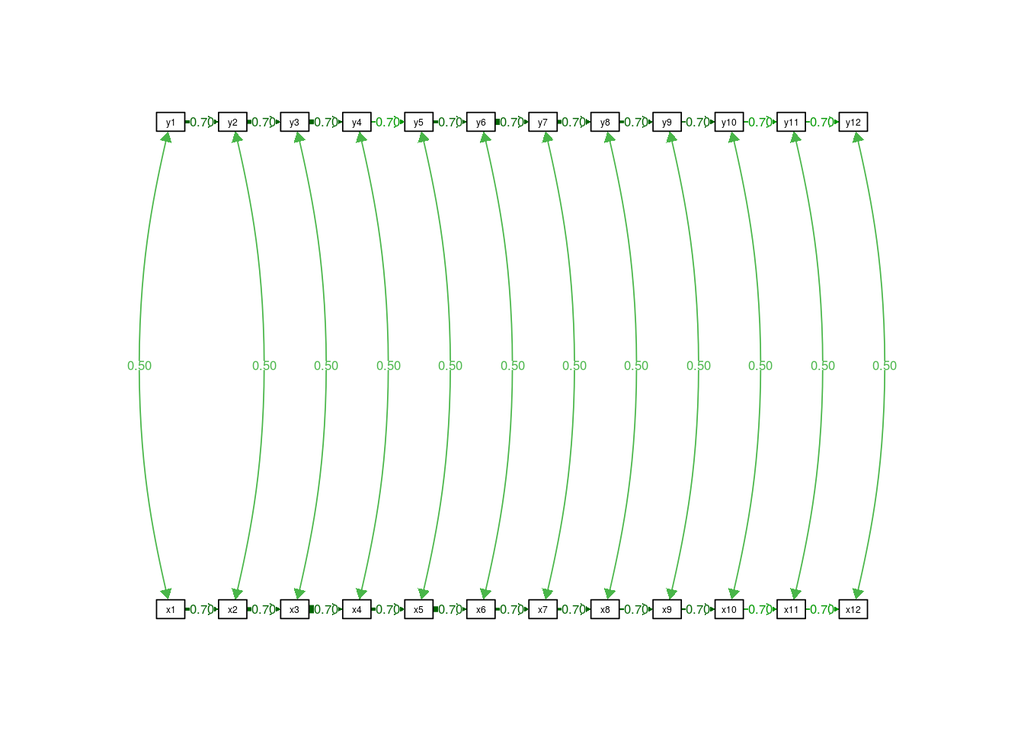

```r
someData <- simulateData(model=generatingModel, sample.nobs=250, empirical=T,
                         auto.fix.first = FALSE, auto.var = FALSE, auto.fix.single = FALSE,
                         auto.cov.lv.x = FALSE, auto.cov.y = FALSE)
fit.DGM <- lavaan(make_clpm_lavaan(generate = F), someData, fixed.x=F)
semPaths(fit.DGM, what='est', rotation=2, exoCov=T, exoVar=T, layout = 'tree2',
         residuals = F, structural = F, sizeLat = 3, sizeMan = 3, sizeMan2 = 2,
         intercepts = F, layoutSplit = F, bifactor = c('omega', 'kappa', paste0('q', 1:12)))
```

```r
# summary(fit.DGM, standardize=T)

someData_long <- someData %>%
  mutate(id = 1:n()) %>%
  gather(key, value, -id) %>%
  extract(key, c('var', 'wave'), '(x|y)(\\d+)') %>%
  spread(var, value) %>%
  mutate(wave = as.numeric(wave)) %>%
  arrange(id, wave)

someData_long$gmean_x <- mean(someData_long$x)
someData_long$gmean_y <- mean(someData_long$y)

someData_long <- someData_long %>%
  group_by(id) %>%
  mutate(x_lag = lag(x),
         y_lag = lag(y),
         id_mean_x = mean(x),
         wcen_x = x - id_mean_x,
         gcen_x = id_mean_x - gmean_x,
         wcen_x_lag = lag(wcen_x),
         id_mean_y = mean(y),
         wcen_y = y - id_mean_y,
         gcen_y = id_mean_y - gmean_y,
         wcen_y_lag = lag(wcen_y))
```

Now we can see what happens if we predict $y_{t}$ from $x_{t-1}$ without accounting for previous levels of y.

```r
lag1.misspec <- lme(y ~ 1 + x_lag, random = ~ 1 | id, data = someData_long,
                 na.action = na.omit)
summary(lag1.misspec)
```

```
## Linear mixed-effects model fit by REML
##  Data: someData_long
##        AIC      BIC    logLik
##   8727.472 8751.147 -4359.736
##
## Random effects:
##  Formula: ~1 | id
##         (Intercept) Residual
## StdDev:   0.6900746 1.092353
##
## Fixed effects: y ~ 1 + x_lag
##                 Value  Std.Error   DF  t-value p-value
## (Intercept) 0.0000000 0.04836027 2499  0.00000       1
## x_lag       0.2798822 0.01872749 2499 14.94499       0
##  Correlation:
##       (Intr)
## x_lag 0
##
## Standardized Within-Group Residuals:
##          Min           Q1          Med           Q3          Max
## -3.971789929 -0.638345071 -0.005193224  0.630063906  3.141142368
##
## Number of Observations: 2750
## Number of Groups: 250
```

We see a very robust effect of lagged x on y, even though no causal effect exists, by construction. This is due to the fact the x_lag is correlated with y_lag, and y_lag is correlated with y.

```r
lag1.ylag <- lme(y ~ 1 + y_lag + x_lag, random = ~ 1 | id, data = someData_long,
                 na.action = na.omit)
summary(lag1.ylag)
```

```
## Linear mixed-effects model fit by REML
##  Data: someData_long
##        AIC     BIC    logLik
##   7833.269 7862.86 -3911.634
##
## Random effects:
##  Formula: ~1 | id
##         (Intercept)  Residual
## StdDev:  0.03921928 0.9997851
##
## Fixed effects: y ~ 1 + y_lag + x_lag
##                 Value  Std.Error   DF  t-value p-value
## (Intercept) 0.0000000 0.01922583 2498  0.00000       1
## y_lag       0.6980061 0.01650849 2498 42.28165       0
## x_lag       0.0000000 0.01650849 2498  0.00000       1
##  Correlation:
##       (Intr) y_lag
## y_lag  0.0
## x_lag  0.0   -0.5
##
## Standardized Within-Group Residuals:
##          Min           Q1          Med           Q3          Max
## -3.503234690 -0.664473912  0.003107336  0.669992962  3.520041940
##
## Number of Observations: 2750
## Number of Groups: 250
```

Once we control for lagged y, which is the true causal effect, we see that lagged x does not have an influence on y

Can we use the residual autocorrelation structure in place of y_lag?

```r
lag1.yAR <-lme(y ~ 1 + x_lag, random = ~ 1 | id, data = someData_long,
               correlation = corAR1(form = ~ wave | id),
               na.action = na.omit)
summary(lag1.yAR)
```

```
## Linear mixed-effects model fit by REML
##  Data: someData_long
##        AIC      BIC   logLik
##   7929.139 7958.732 -3959.57
##
## Random effects:
##  Formula: ~1 | id
##         (Intercept) Residual
## StdDev:   0.1451315 1.343548
##
## Correlation Structure: AR(1)
##  Formula: ~wave | id
##  Parameter estimate(s):
##       Phi
## 0.6758963
## Fixed effects: y ~ 1 + x_lag
##                  Value  Std.Error   DF  t-value p-value
## (Intercept) 0.00000000 0.05045094 2499 0.000000  1.0000
## x_lag       0.02840258 0.01930589 2499 1.471188  0.1414
##  Correlation:
##       (Intr)
## x_lag 0
##
## Standardized Within-Group Residuals:
##         Min          Q1         Med          Q3         Max
## -3.87371233 -0.70701707  0.01075362  0.70636263  3.41528868
##
## Number of Observations: 2750
## Number of Groups: 250
```

Including the residual AR stucture helps, but we still see a positive estimate for the effect of x_lag. Since we’re working with data that reflects exaclty the data generating model, we should get exactly the same numbers that we put in – so this positive estimate is cause for concern. How much does this inflate our false positive rate if we sample randomly from the data generating model (as we do when we run a study)?

If we’re just estimating contemporaneous effects without allowing for possible lagged causes what do we get?

```r
cont1.y <-lme(y ~ 1 + x, random = ~ 1 | id, data = someData_long,
              na.action = na.omit)
summary(cont1.y)
```

```
## Linear mixed-effects model fit by REML
##  Data: someData_long
##        AIC      BIC    logLik
##   8825.798 8849.821 -4408.899
##
## Random effects:
##  Formula: ~1 | id
##         (Intercept) Residual
## StdDev:   0.6377892 0.973903
##
## Fixed effects: y ~ 1 + x
##             Value  Std.Error   DF  t-value p-value
## (Intercept)   0.0 0.04408245 2749  0.00000       1
## x             0.5 0.01581666 2749 31.61223       0
##  Correlation:
##   (Intr)
## x 0
##
## Standardized Within-Group Residuals:
##          Min           Q1          Med           Q3          Max
## -3.816335374 -0.678633182 -0.009110479  0.636465462  3.236979182
##
## Number of Observations: 3000
## Number of Groups: 250
```

```r
cont1.yAR <-lme(y ~ 1 + x, random = ~ 1 | id, data = someData_long,
               correlation = corAR1(form = ~ wave | id),
               na.action = na.omit)
summary(cont1.yAR)
```

```
## Linear mixed-effects model fit by REML
##  Data: someData_long
##       AIC      BIC   logLik
##   7710.68 7740.708 -3850.34
##
## Random effects:
##  Formula: ~1 | id
##         (Intercept) Residual
## StdDev: 0.002046962 1.151257
##
## Correlation Structure: AR(1)
##  Formula: ~wave | id
##  Parameter estimate(s):
##       Phi
## 0.6742303
## Fixed effects: y ~ 1 + x
##             Value  Std.Error   DF  t-value p-value
## (Intercept)   0.0 0.04108792 2749  0.00000       1
## x             0.5 0.01581666 2749 31.61223       0
##  Correlation:
##   (Intr)
## x 0
##
## Standardized Within-Group Residuals:
##          Min           Q1          Med           Q3          Max
## -4.088430990 -0.703776293  0.002075657  0.686805409  3.537266795
##
## Number of Observations: 3000
## Number of Groups: 250
```

This looks right, ’cause this is very close to the generating model with no possible confounds.

# Numerous simulations

```r
generate_data <- function(n = 250, gen_mod, wcen = FALSE){
  someData <- simulateData(model=gen_mod, sample.nobs=n, empirical=F)

  someData_long <- someData %>%
    mutate(id = 1:n()) %>%
    gather(key, value, -id) %>%
    extract(key, c('var', 'wave'), '(x|y)(\\d+)') %>%
    spread(var, value) %>%
    mutate(wave = as.numeric(wave)) %>%
    arrange(id, wave) %>%
    group_by(id) %>%
    mutate(x_lag = lag(x),
           y_lag = lag(y))

  if(wcen){
    someData_long$gmean_x <- mean(someData_long$x)
    someData_long$gmean_y <- mean(someData_long$y)
    someData_long <- someData_long %>%
      group_by(id) %>%
      mutate(id_mean_x = mean(x),
             wcen_x = x - id_mean_x,
             gcen_x = id_mean_x - gmean_x,
             wcen_x_lag = lag(wcen_x),
             id_mean_y = mean(y),
             wcen_y = y - id_mean_y,
             gcen_y = id_mean_y - gmean_y,
             wcen_y_lag = lag(wcen_y))
  }

  return(someData_long)
}

run_model <- function(n = 250, gen_mod, wcen = FALSE, use_lag_y = FALSE, use_lme4 = FALSE, wcen_re = FALSE){
  someData_long <- generate_data(n = n, gen_mod = gen_mod, wcen = wcen)

  if(wcen){
    if(use_lag_y){
      if(use_lme4){
        if(wcen_re){
          lag1.yAR <-lmer(y ~ 1 + wcen_y_lag + gcen_y + wcen_x_lag + gcen_x + (1 + wcen_x_lag || id), data = someData_long,
                          REML = TRUE,
                          na.action = na.omit)
        } else {
          lag1.yAR <-lmer(y ~ 1 + wcen_y_lag + gcen_y + wcen_x_lag + gcen_x + (1 | id), data = someData_long,
                          REML = TRUE,
                          na.action = na.omit)
        }
      } else {
        lag1.yAR <-lme(y ~ 1 + wcen_y_lag + gcen_y + wcen_x_lag + gcen_x, random = ~ 1 | id, data = someData_long,
                       na.action = na.omit)
      }
    } else {
      lag1.yAR <-lme(y ~ 1 + wcen_x_lag + gcen_x, random = ~ 1 | id, data = someData_long,
                     correlation = corAR1(form = ~ wave | id),
                     na.action = na.omit)
    }
    if(use_lme4){
      asum <- coef(summary(lag1.yAR, ddf = 'Satterthwaite'))
      x_lag_p <- asum['wcen_x_lag', 'Pr(>|t|)']
      x_lag_bias <- asum['wcen_x_lag', 'Estimate']
    } else {
      asum <- summary(lag1.yAR)
      x_lag_p <- asum$tTable['wcen_x_lag', 'p-value']
      x_lag_bias <- asum$tTable['wcen_x_lag', 'Value']
    }
  } else {
    if(use_lag_y){
      lag1.yAR <-lme(y ~ 1 + y_lag + x_lag, random = ~ 1 | id, data = someData_long,
                     na.action = na.omit)
    } else {
      lag1.yAR <-lme(y ~ 1 + x_lag, random = ~ 1 | id, data = someData_long,
                     correlation = corAR1(form = ~ wave | id),
                     na.action = na.omit)
    }

    asum <- summary(lag1.yAR)
    x_lag_p <- asum$tTable['x_lag', 'p-value']
    x_lag_bias <- asum$tTable['x_lag', 'Value']
  }
  return(data.frame(n = n, x_lag_p = x_lag_p, x_lag_bias = x_lag_bias))
}

reps_per_n = 1e3
rerun = FALSE
N_seq = seq(30, 270, 40)
cores = 7

if(rerun){
  library(parallel)
  system.time(no_wcen_ar_reps <- mclapply(N_seq,
                                       function(n) {
                                         somereps <- dplyr::bind_rows(
                                           replicate(reps_per_n,
                                                     run_model(n, generatingModel, wcen = F),
                                                     simplify = F))
                                         return(somereps)
                                       }, mc.cores = cores))
  saveRDS(no_wcen_ar_reps, 'no_wcen_ar.RDS')

  system.time(wcen_ar_reps <- mclapply(N_seq,
                                     function(n) {
                                       somereps <- dplyr::bind_rows(
                                         replicate(reps_per_n,
                                                   run_model(n, generatingModel, wcen = T),
                                                   simplify = F))
                                       return(somereps)
                                     }, mc.cores = cores))
  saveRDS(wcen_ar_reps, 'wcen_ar.RDS')

  system.time(no_wcen_ylag_reps <- mclapply(N_seq,
                                          function(n) {
                                            somereps <- dplyr::bind_rows(
                                              replicate(reps_per_n,
                                                        run_model(n, generatingModel, wcen = F, use_lag_y = T),
                                                        simplify = F))
                                            return(somereps)
                                          }, mc.cores = cores))
  saveRDS(no_wcen_ylag_reps, 'no_wcen_ylag_reps.RDS')

  system.time(wcen_ylag_reps <- mclapply(N_seq,
                                       function(n) {
                                         somereps <- dplyr::bind_rows(
                                           replicate(reps_per_n,
                                                     run_model(n, generatingModel, wcen = T, use_lag_y = T),
                                                     simplify = F))
                                         return(somereps)
                                       }, mc.cores = cores))
  saveRDS(wcen_ylag_reps, 'wcen_ylag_reps.RDS')

  system.time(wcen_ylag_l4_reps <- mclapply(N_seq,
                                            function(n) {
                                              somereps <- dplyr::bind_rows(
                                                replicate(reps_per_n,
                                                          run_model(n, generatingModel, wcen = T, use_lag_y = T,
                                                                    use_lme4 = T, wcen_re = F),
                                                          simplify = F))
                                              return(somereps)
                                            }, mc.cores = cores))
  saveRDS(wcen_ylag_l4_reps, 'wcen_ylag_l4_reps.RDS')

  system.time(wcen_ylag_l4_wcenre_reps <- mclapply(N_seq,
                                                   function(n) {
                                                     somereps <- dplyr::bind_rows(
                                                       replicate(reps_per_n,
                                                                 run_model(n, generatingModel, wcen = T, use_lag_y = T,
                                                                           use_lme4 = T, wcen_re = T),
                                                                 simplify = F))
                                                     return(somereps)
                                                   }, mc.cores = cores))
  saveRDS(wcen_ylag_l4_wcenre_reps, 'wcen_ylag_l4_wcenre_reps.RDS')
} else {
  no_wcen_ar_reps <- readRDS('no_wcen_ar.RDS')
  wcen_ar_reps <- readRDS('wcen_ar.RDS')
  no_wcen_ylag_reps <- readRDS('no_wcen_ylag_reps.RDS')
  wcen_ylag_reps <- readRDS('wcen_ylag_reps.RDS')
  wcen_ylag_l4_reps <- readRDS('wcen_ylag_l4_reps.RDS')
  wcen_ylag_l4_wcenre_reps <- readRDS('wcen_ylag_l4_wcenre_reps.RDS')
}
```

# Using AR residual structure to account for stability

```
lag1.yAR <-lme(y ~ 1 + x_lag, random = ~ 1 | id, data = someData_long,
               correlation = corAR1(form = ~ wave | id),
               na.action = na.omit)
```

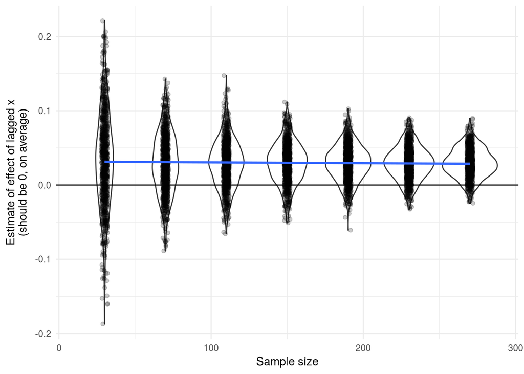

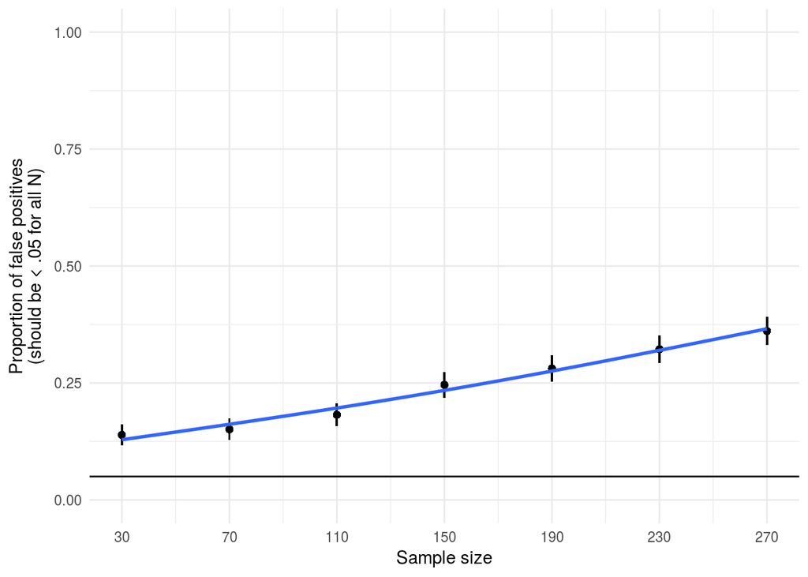

```r
plot_results(no_wcen_ar_reps, max_fp = 1)
```

What we see here is a consistent bias in the estimates of the effect of lagged x on y. As our sample size increases, we are better and better powered, which means we erroneously reject the null more often due to this bias. In other words, if we are powered to detect an effect of lagged x on y, we are powered to mistake this bias for a causal effect, even using the AR structure to adjust for the stability of y.

# Using lagged DV to account for stability

```
lag1.yAR <-lme(y ~ 1 + y_lag + x_lag, random = ~ 1 | id, data = someData_long,
               na.action = na.omit)
```

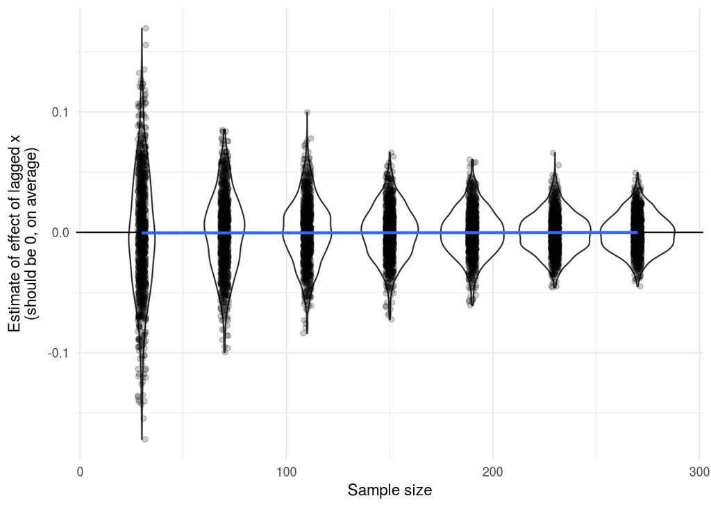

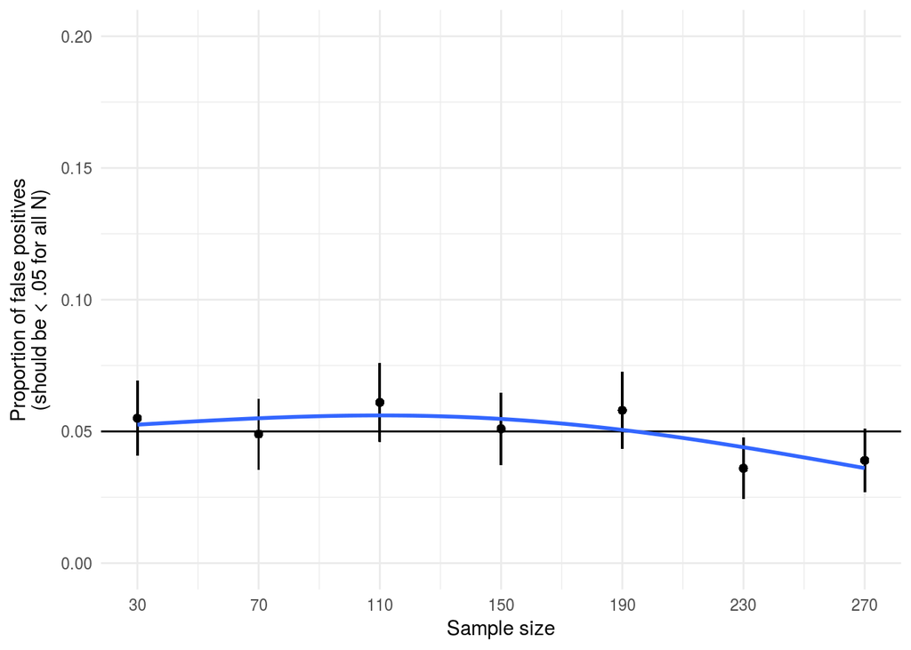

```r
plot_results(no_wcen_ylag_reps)
```

Here we see no bias in the estimate of the effect of lagged x on y, and correspondingly our error rate is controlled appropriately.

# AR with within-person-centering

We might want to create separate IVs for the within-person versus the between-person effect. In this example, I’ve created a variable that is just each person’s mean across all waves, centered at the group mean (gcen) and a within-person variable that is each person’s score at a wave minus their mean.

This is in line with the advice in:

> Wang, L. (Peggy), & Maxwell, S. E. (2015). On disaggregating between-person and within-person effects with longitudinal data using multilevel models. Psychological Methods, 20(1), 63–83. https://doi.org/10.1037/met0000030

```
lag1.yAR <-lme(y ~ 1 + wcen_x_lag + gcen_x, random = ~ 1 | id, data = someData_long,
               correlation = corAR1(form = ~ wave | id),
               na.action = na.omit)
```

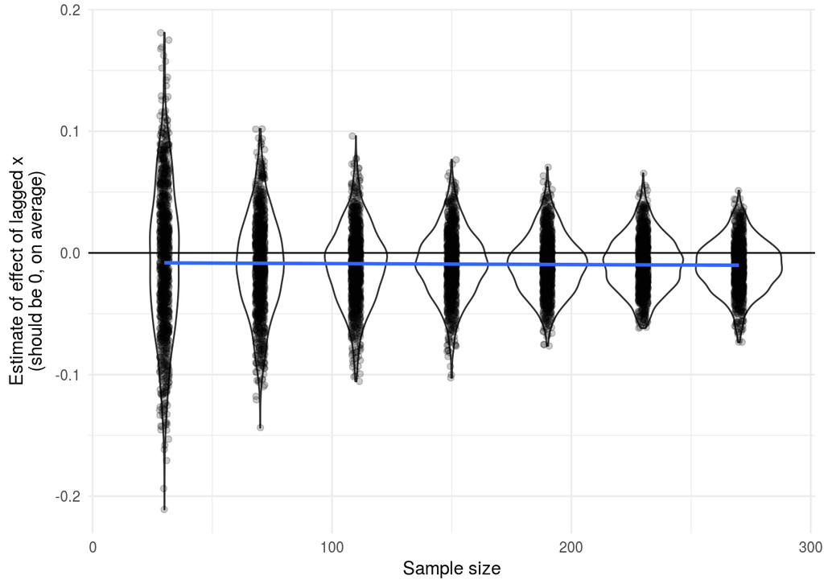

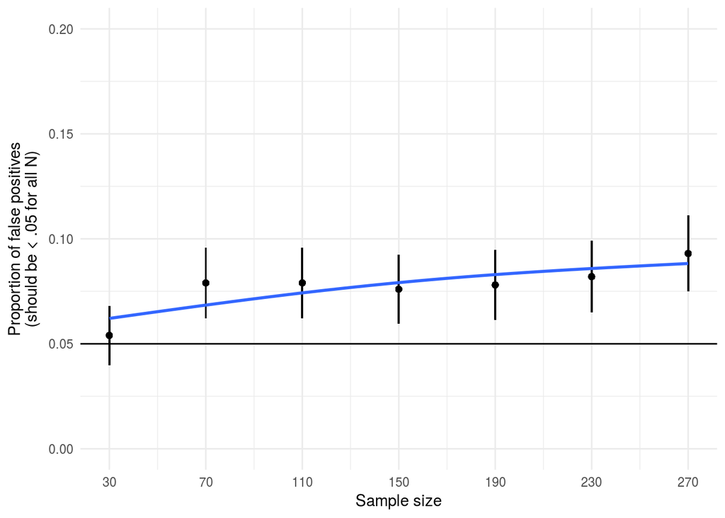

```r
plot_results(wcen_ar_reps)
```

Interstingly, when we within-person center the lagged x variable, we see a negative bias. This is also picked up in the p-values as our sample size increases.

# Lagged y with within-person-centering

Note that when we within-person center the IV, x, we also within-person center the lagged DV, y, and include both the within- and between- person variables. If you don’t do this, wow, the false positive error rate goes way up. I’m not quite sure why this is (simulations not shown).

```
lag1.yAR <-lme(y ~ 1 + wcen_y_lag + gcen_y + wcen_x_lag + gcen_x, random = ~ 1 | id, data = someData_long,
               na.action = na.omit)
```

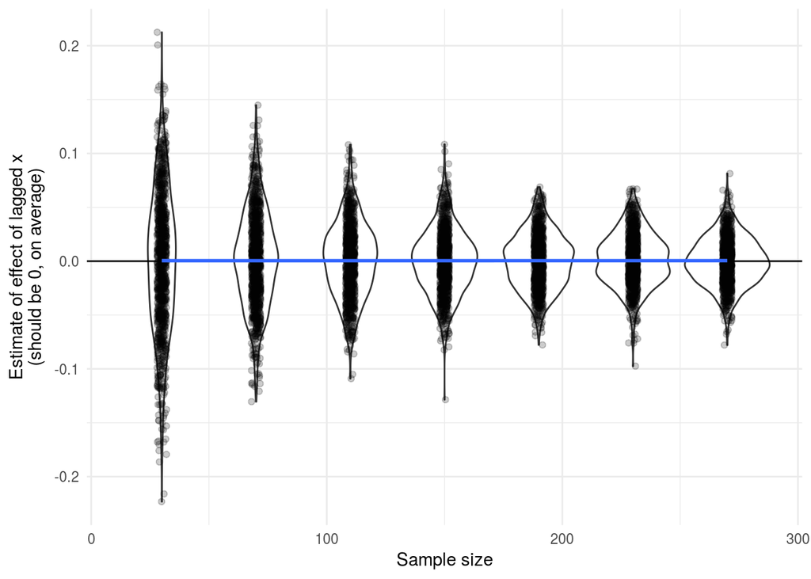

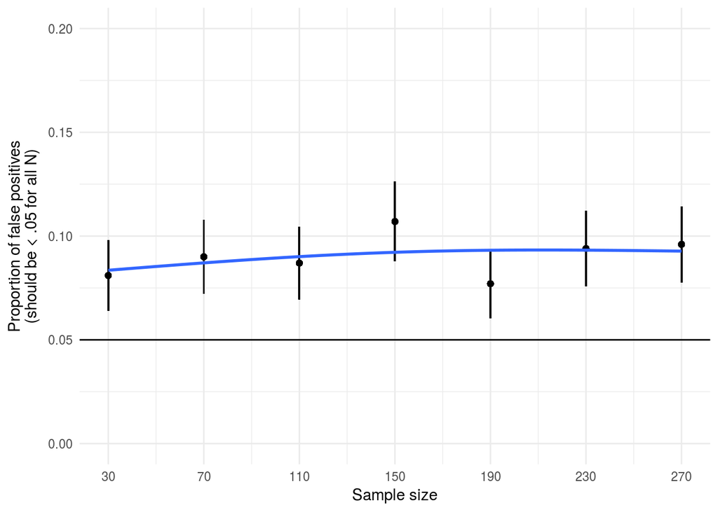

```r
plot_results(wcen_ylag_reps)
```

The error rate in this case is still higher than the nominal rate, but since bias is 0, this may be due to a problem with the standard errors, or the DF being used. Perhaps another possibility is that the random effects are mispecified. I’m not sure why this is, but we can test whether using the Satterthwaite correction, or including a random effect of the within-person predictor helps.

# Lagged y with within-person-centering, Satterthwaite correction

Perhaps using the Satterthwaite correction will appropriately adjust the *p*-values.

```
lag1.yAR <-lmer(y ~ 1 + wcen_y_lag + gcen_y + wcen_x_lag + gcen_x + (1 | id), data = someData_long,
               REML = TRUE,
               na.action = na.omit)
summary(lag1.yAR, ddf = 'Satterthwaite')
```

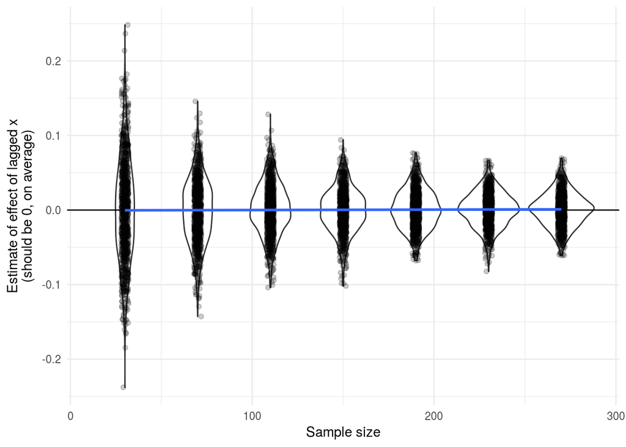

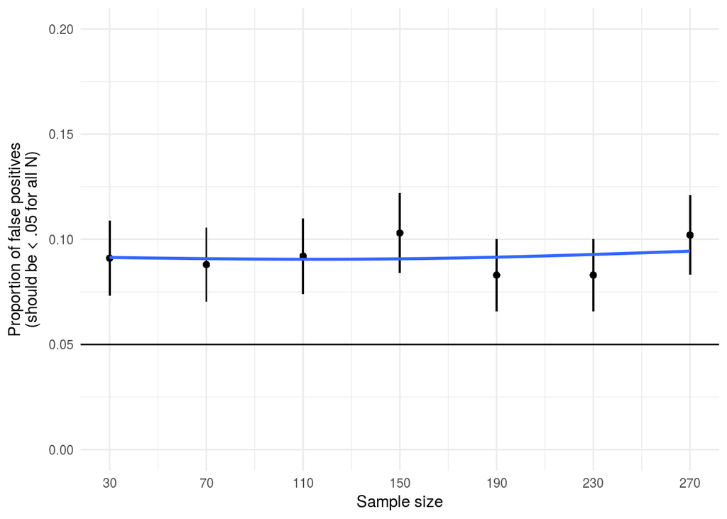

```r
plot_results(wcen_ylag_l4_reps)
```

Bummer. Still a higher than expected error rate.

# Lagged y with within-person-centering, Satterthwaite correction + WCEN RE

The last thing I’ll try is to add the within-person centered lagged predictor as random effect.

```
lag1.yAR <-lmer(y ~ 1 + wcen_y_lag + gcen_y + wcen_x_lag + gcen_x + (1 + wcen_x_lag || id), data = someData_long,
               REML = TRUE,
               na.action = na.omit)
summary(lag1.yAR, ddf = 'Satterthwaite')
```

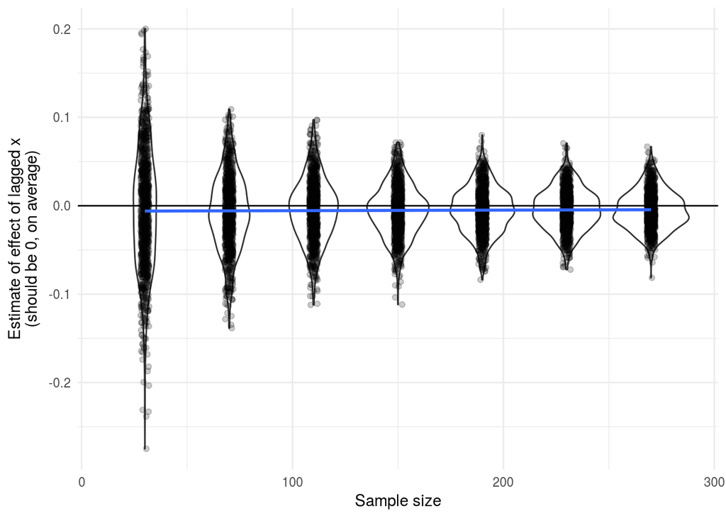

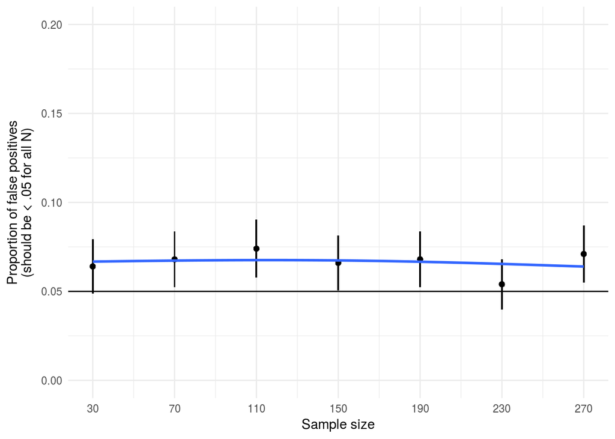

```r
plot_results(wcen_ylag_l4_wcenre_reps)
```

That looks like it helped a little bit, but it also seems to induce a small negative bias.